# Analysis of Bryophyte Richness and Diversity in the Americas

Carter Powell, Jackie O’Malley, and Julia Eckberg

```r
require(knitr)
require(latexpdf)
require(sp)
require(vegan)
require(raster)
require(rasterVis)
require(wesanderson)
require(ggplot2)
require(gridExtra)
require(sf)
require(rgdal)
```

#Load blank raster and cell richness data + extract cell IDs and create vector for all cells #Change file for BetaMat and CellRichness depending on if you want to map bryophytes, mosses, liverworts, etc.

```r
BlankRas <-raster("Data/blank_100km_raster.tif")
BetaMat <- readRDS("Data/BetaMat.rds")
CellRichness <- readRDS("Data/CellRichness.rds")
CellID <- CellRichness$CellID
CellVec <- c(1:15038)
```

#Identify occupied cells that are adJent to each occuppied cell + convert to vector

```r
neighbor <- function(CellVec) {(adjacent(BlankRas, CellVec, directions=8, pairs=FALSE, target=CellID, sorted=TRUE, include=FALSE, id=FALSE))}
Neighbors <- lapply(CellVec, neighbor)
names(Neighbors) <- CellVec

bryneighbors <- Neighbors[CellID]
bryneighborvect <- unlist(lapply(bryneighbors, length))
```

#Separate out occuppied cells with 8 and 7 occuppied neighbors

```r
Cell8 <- CellID[which(bryneighborvect==8)]
Neighbors8 <-Neighbors[Cell8]
Neighbors8 <- data.frame(Neighbors8)
names(Neighbors8) <- Cell8

Cell7 <- CellID[which(bryneighborvect==7)]
Neighbors7 <- Neighbors[Cell7]
Neighbors7 <- data.frame(Neighbors7)
names(Neighbors7) <- Cell7
```

#Make beta diversity matrix for all cells

```r
BetaMat<-as.matrix(BetaMat)
row.names(BetaMat) <- CellID
names(BetaMat) <- CellID
```

#Make beta diversity matrix for cells with 8 neighbors and cells with 7 neighbors

```r
BetaMat8<- BetaMat[!Cell8, !Cell8, drop=TRUE]
inx8 <- match(as.character(Cell8), rownames(BetaMat8))
BetaMat8 <- BetaMat8[inx8,inx8]

BetaMat7 <- BetaMat[!Cell7, !Cell7, drop=TRUE]
inx7 <- match(as.character(Cell7), rownames(BetaMat7))
BetaMat7 <- BetaMat7[inx7,inx7]
```

#For each cell, pairwise beta diversity is calculated for that focal cell and each of its 8 (or 7) neighbors, and the mean of those values is found

```r
Cell8CH <- as.character(Cell8)
Beta8 <- lapply(Cell8CH, function(x)mean(BetaMat[x, as.character(Neighbors8[,x])]))
names(Beta8) <- Cell8CH

Cell7CH <- as.character(Cell7)
Beta7 <- lapply(Cell7CH, function(x)mean(BetaMat[x, as.character(Neighbors7[,x])]))
names(Beta7) <- Cell7CH
```

#Plot mean pairwise beta diversity by Cell ID and convert to dissimilarity using 1-x where x is Jaccard similarity

```r
Beta7Vec<-unlist(Beta7)
Beta8Vec<-unlist(Beta8)

BetaVec <- rep(0, 15038)

BetaVec[Cell8]<-Beta8Vec
BetaVec[Cell7]<-Beta7Vec

BetaVec[BetaVec==0]<-NA
BetaVec <- 1-BetaVec
```

#Create colorscheme

```r
cols <- (wes_palette("Zissou1", 500, type = "continuous"))
```

#Add continental and mountainous outlines

```r
nw_mount <- shapefile("Data/MapOutlines/Mountains/Koeppen-Geiger_biomes.shp")
nw_bound <- shapefile("Data/MapOutlines/Global_bound/Koeppen-Geiger_biomes.shp")

nw_mount_sf <- st_as_sf(nw_mount)
nw_bound_sf <- st_as_sf(nw_bound)
```

#Map beta diversity, adjust minimum value to remove outliers

```r
BetaRaster <- setValues(BlankRas, BetaVec)
BetaPoints<-rasterToPoints(BetaRaster)
BetaDF <- data.frame(BetaPoints)
colnames(BetaDF) <- c("Longitude", "Latitude", "Beta")

theme_set(theme_void())
```

[output not shown]

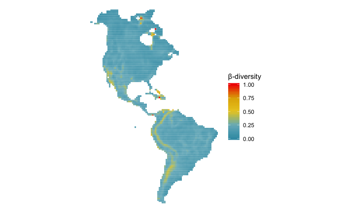

```r
RawBetaMap <- ggplot() + geom_tile(data=BetaDF, aes(x=Longitude, y=Latitude, fill=Beta)) +
    scale_fill_gradientn(name="β-diversity", colours=cols, na.value="transparent", limits = c(0,1)) +
    coord_equal()
RawBetaMap
```

#Convert UTM to longitude and latitude

```r
LongLatBetaVec <- rep(0, 15038)
LongLatBetaVec[Cell8]<-Beta8Vec
LongLatBetaVec[Cell7]<-Beta7Vec
LongLatBetaVec[LongLatBetaVec==0]<-NA
LongLatBetaVec <- 1-LongLatBetaVec

LongLatBetaRaster <- setValues(BlankRas, LongLatBetaVec)
LongLatBetaPoints<-rasterToPoints(LongLatBetaRaster)
LongLatBetaDF <- data.frame(LongLatBetaPoints)
colnames(LongLatBetaDF) <- c("Longitude", "Latitude", "Beta")

coordinates(LongLatBetaDF) <- ~Longitude+Latitude
proj4string(LongLatBetaDF) <- CRS("+proj=utm +zone=10")
BetaLongLat <- spTransform(LongLatBetaDF, CRS("+proj=longlat"))
LongLatBetaDF <- data.frame(BetaLongLat)
LongLatBetaDF[c("Longitude", "Latitude", "Beta")]
```

|  | Longitude | Latitude | Beta |
| --- | --- | --- | --- |
| 1 | -175.0703 | 50.63424 | 0.06256618 |
| 2 | -174.1878 | 51.18168 | 0.05339368 |
| 3 | -173.2773 | 51.72637 | 0.06561409 |
| 4 | -172.3376 | 52.26776 | 0.05160097 |
| 5 | -171.3679 | 52.80529 | 0.06673209 |
| 6 | -170.3669 | 53.33837 | 0.07108604 |
| 7 | -135.0226 | 62.74943 | 0.06248401 |
| 8 | -133.0965 | 62.90262 | 0.07002320 |
| 9 | -131.1494 | 63.02939 | 0.07232203 |
| 10 | -129.1853 | 63.12925 | 0.08869929 |

[output cut: 990 more lines]

```r
BetaLongLat <- data.frame(BetaLongLat)
colnames(BetaLongLat) <- c("Beta", "Longitude", "Latitude")

saveRDS(LongLatBetaRaster, file="Data/LongLatBetaRaster.rds")
```

#Beta diversity by latitude scatterplots

```r
BetaLongLat$pc <- predict(prcomp(~Latitude+Beta, BetaLongLat))[,1]
cols2 <- rev(wes_palette("Zissou1", 1, type = "continuous"))

BetaLongLat
```

|  | Beta | Longitude | Latitude | None | pc |
| --- | --- | --- | --- | --- | --- |
| 1 | 0.06256618 | -175.0703 | 50.63424 | TRUE | -43.61238 |
| 2 | 0.05339368 | -174.1878 | 51.18168 | TRUE | -44.15983 |
| 3 | 0.06561409 | -173.2773 | 51.72637 | TRUE | -44.70450 |
| 4 | 0.05160097 | -172.3376 | 52.26776 | TRUE | -45.24590 |
| 5 | 0.06673209 | -171.3679 | 52.80529 | TRUE | -45.78342 |
| 6 | 0.07108604 | -170.3669 | 53.33837 | TRUE | -46.31650 |
| 7 | 0.06248401 | -135.0226 | 62.74943 | TRUE | -55.72756 |
| 8 | 0.07002320 | -133.0965 | 62.90262 | TRUE | -55.88074 |
| 9 | 0.07232203 | -131.1494 | 63.02939 | TRUE | -56.00752 |
| 10 | 0.08869929 | -129.1853 | 63.12925 | TRUE | -56.10736 |

[output cut: 990 more lines]

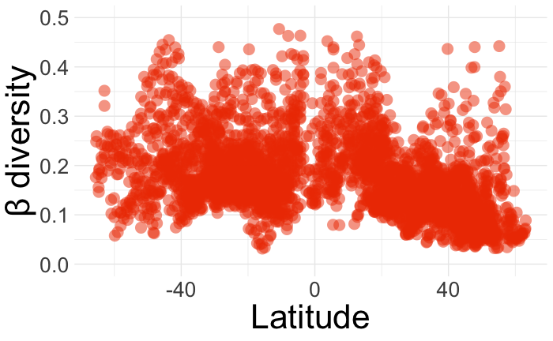

```r
BetaScatterplot <- ggplot(BetaLongLat, aes(Latitude, Beta)) + geom_point(shape = 16, size = 5, show.legend = FALSE, alpha=0.5, color = "orangered2") + ylab("β diversity") + ylim(0,0.5)+ theme_minimal() + theme(axis.title.y = element_text(size=32), axis.title.x = element_text(size=32),  axis.text = element_text(size=20))

BetaScatterplot
```

```r
OutlierBetaVec <- rep(0, 15038)
OutlierBetaVec[Cell8]<-Beta8Vec
OutlierBetaVec[Cell7]<-Beta7Vec
OutlierBetaVec[OutlierBetaVec==0]<-NA
OutlierBetaVec[OutlierBetaVec>0.5]<-NA

OutlierBetaRaster <- setValues(BlankRas, OutlierBetaVec)
OutlierBetaPoints<-rasterToPoints(OutlierBetaRaster)
OutlierBetaDF <- data.frame(OutlierBetaPoints)
colnames(OutlierBetaDF) <- c("Longitude", "Latitude", "Beta")

theme_set(theme_void())
OutlierBetaMap <- gplot(OutlierBetaRaster, maxpixels=15038) +  geom_tile(aes(fill = value)) +
    scale_fill_gradientn(colours="black", na.value="transparent", limits = c(0,1)) + theme(legend.position = "none") +
    coord_equal()
```

#Map beta diversity with values over 0.5 shown in dark grey (19 values are over 0.5) #theme_void for white background, theme_gray for latitude curves

```r
source("Functions/gplot_data.R")
gplotB<- gplot_data(BetaRaster)
gplotOutlier<- gplot_data(OutlierBetaRaster)

BetaMap <- ggplot() +
  geom_tile(data = dplyr::filter(gplotOutlier, !is.na(value)),
            aes(x = x, y = y), fill = "gray25") +
  geom_tile(data = gplotB,
            aes(x = x, y = y, fill = value)) +
  scale_fill_gradientn(name="β diversity", colours=cols, na.value="transparent", limits = c(0,0.5)) +
  coord_quickmap() + geom_sf(data = nw_bound_sf, size = 0.5, fill=NA) +
  geom_sf(data = nw_mount_sf, size = 0.5, alpha=0.1) + theme_gray() +
  theme(legend.text=element_text(size=20), legend.title=element_text(size=0), axis.title = element_blank())
BetaMap

png("Figures/beta.png", width = 1000, height = 1000, pointsize = 30)
```

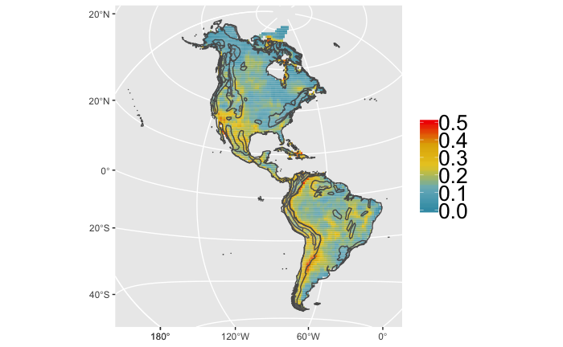

```r
BetaMap
dev.off()
```

#Map richness (alpha diversity)

```r
RichnessVec <- readRDS("Data/RichnessVec.rds")
RichnessVec[which(RichnessVec==0)]=NA
RichnessRaster <- setValues(BlankRas, RichnessVec)
saveRDS(RichnessRaster, "Data/RichnessRaster.rds")

RichnessDF <- rasterToPoints(RichnessRaster)
RichnessDF <- data.frame(RichnessDF)
colnames(RichnessDF) <- c("Longitude", "Latitude", "Alpha")

RichnessMap <- ggplot() + geom_tile(data=RichnessDF, aes(x=Longitude, y=Latitude, fill=Alpha)) +
    scale_fill_gradientn(name="α diversity", colours=cols, na.value="transparent") +
    coord_equal() +
 geom_sf(data = nw_bound_sf, size = 0.5, fill=NA) +
  geom_sf(data = nw_mount_sf, size = 0.5, alpha=0.1) + theme_void() +
  theme(legend.text=element_text(size=20), legend.title=element_text(size=32))
RichnessMap

png("Figures/alpha.png", width = 1000, height = 1000, pointsize = 30)
```

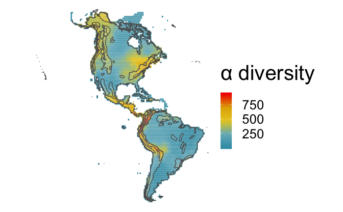

```r
RichnessMap
dev.off()
```

#Richness convert to long-lat

```r
coordinates(RichnessDF) <- ~Longitude+Latitude
proj4string(RichnessDF) <- CRS("+proj=utm +zone=10")
AlphaLongLat <- spTransform(RichnessDF, CRS("+proj=longlat"))
AlphaLongLat <- data.frame(AlphaLongLat)
colnames(AlphaLongLat) <- c("Alpha", "Longitude", "Latitude")
```

#Map alpha and beta diversity side-by-side and save as png

```r
png("Figures/bothmaps.png", width = 1000, height = 1000, pointsize = 20)
grid.arrange(RichnessMap, BetaMap, ncol=2)
dev.off()
```

#Alpha diversity by latitude

```r
theme_set(theme_gray())
AlphaScatterplot <- ggplot(AlphaLongLat, aes(Latitude, Alpha)) + geom_point(shape = 16, size = 5, show.legend = FALSE, alpha=0.5, color = "orangered2") + ylab("α diversity") + xlab(" ") + theme_minimal() + theme(axis.title.y = element_text(size=32), axis.text.y = element_text(size=20), axis.text.x = element_text(size=0))
AlphaScatterplot

png("Figures/AlphaBetaScatter.png", width = 1000, height = 1000, pointsize = 20)
```

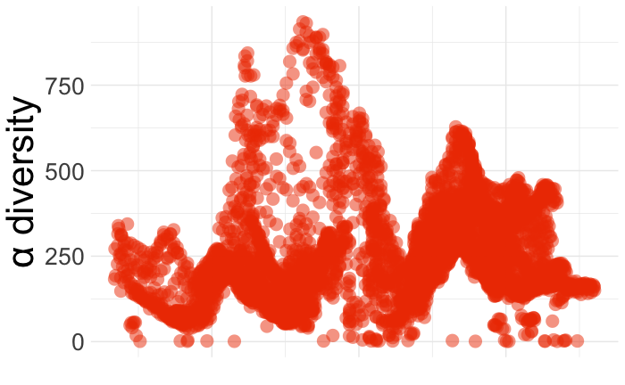

```r
grid.arrange(AlphaScatterplot, BetaScatterplot, ncol=1)
dev.off()
```